# Презентация по лабораторной работе №13

Дисциплина: Архитектура компьютеров и операционные системы

Гусев Степан Андреевич

1032242444@rudn.ru

Российский университет дружбы народов

2026-04-08

# Информация

**Презентация по лабораторной работе №13**

**Автор:** Гусев Степан Андреевич

**Преподаватель:** Кулябов Дмитрий Сергеевич, д.ф.-м.н., профессор кафедры теории вероятностей и кибербезопасности

Российский университет дружбы народов

## Докладчик

- Гусев Степан Андреевич
- Студент программы “Бизнес-информатика”
- Российский университет дружбы народов им. П. Лумумбы
- 1032242444@rudn.ru
- https://github.com/stepagusev

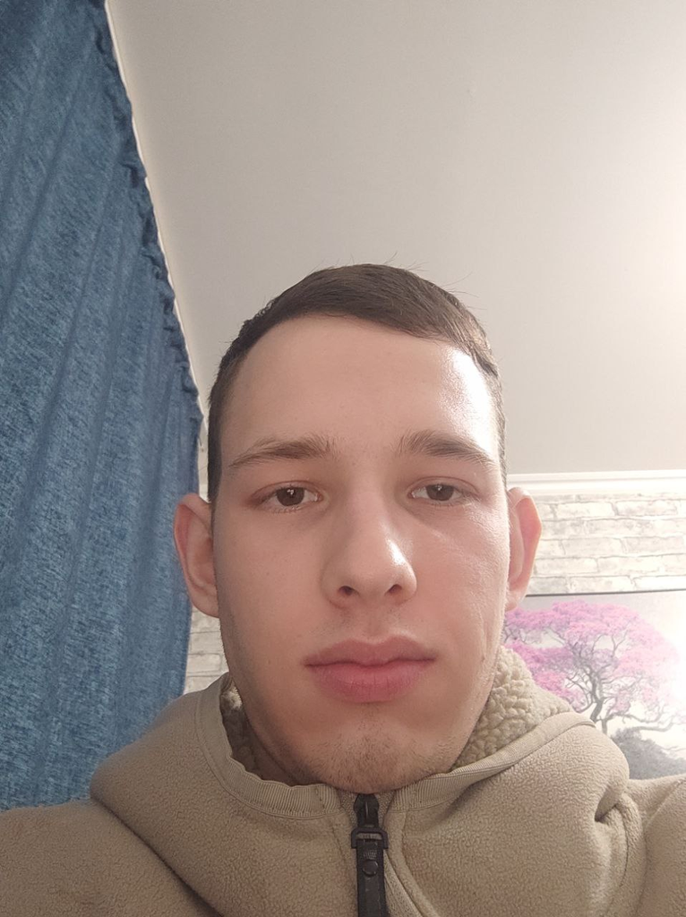

## Цель

Изучить основы программирования в оболочке ОС UNIX. Научится писать более сложные командные файлы с использованием логических управляющих конструкций и циклов.

## Задание

1. Используя команды getopts grep, написать командный файл, который анализирует командную строку с ключами, а затем ищет в указанном файле нужные строки, определяемые ключом -p.
2. Написать на языке Си программу, которая вводит число и определяет, является ли оно больше нуля, меньше нуля или равно нулю. Командный файл должен вызывать эту программу и выдать сообщение о том, какое число было введено.
3. Написать командный файл, создающий указанное число файлов, умеющий удалять все созданные им файлы.
4. Написать командный файл, который с помощью команды tar запаковывает в архив все файлы в указанной директории, изменённые менее недели тому назад.

# Выполнение лабораторной работы

## Скрипт 1

Создал файл 1.sh, дал права на выполнение, ввёл код и запустил скрипт.

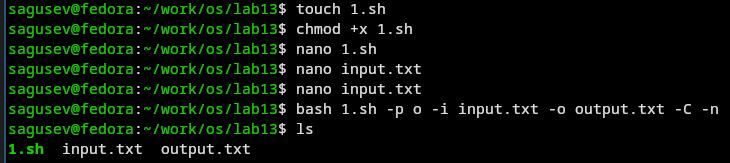

Рисунок 1: Создание файла 1

## Скрипт 1

Текст скрипта 1.sh.

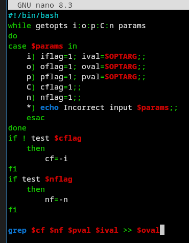

Рисунок 2: Скрипт 1

## Скрипт 1

Текст input.txt.

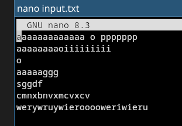

Рисунок 3: Текст input.txt

## Скрипт 1

Результат работы скрипта.

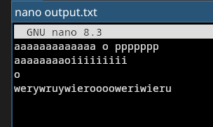

Рисунок 4: Текст output.txt

## Скрипт 2

Создал файл 2.sh, дал права на выполнение, создал файл 2.с, дал права на выполнение.

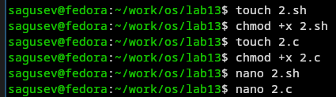

Рисунок 5: Создание файла 2

## Скрипт 2

Текст скрипта 2.sh.

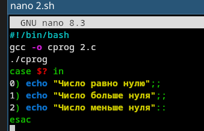

Рисунок 6: Скрипт 2

## Скрипт 2

Текст кода на Си.

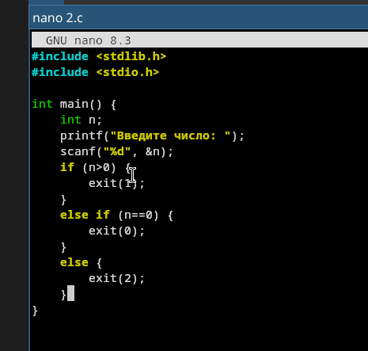

Рисунок 7: Код C

## Скрипт 2

Запустил скрипт несколько раз, чтобы проверить все варианты.

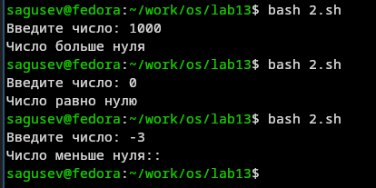

Рисунок 8: Результат работы скрипта 2

## Скрипт 3

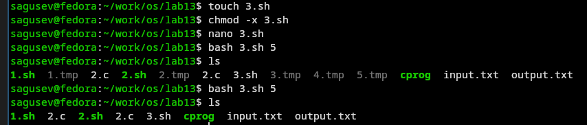

Рисунок 9: Создание файла 3

## Скрипт 3

Текст скрипта 3.sh.

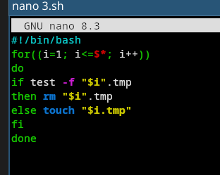

Рисунок 10: Скрипт 3

## Скрипт 4

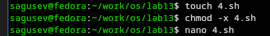

Рисунок 11: Создание файла 4

## Скрипт 4

Текст скрипта 4.sh.

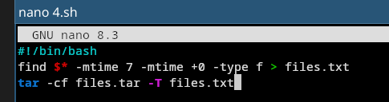

Рисунок 12: Скрипт 4

## Скрипт 4

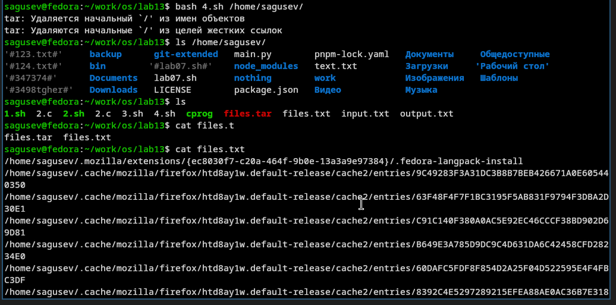

Рисунок 13: Результат работы скрипта 4

# Выводы

## Выводы

Я изучил основы программирования в оболочке ОС UNIX и научился писать более сложные командные файлы с использованием логических управляющих конструкций и циклов.